Yongsang Park

## 1 Pumpkins

```r
n = 20
pumpkins = c(9.6, 8.8, 5.1, 9.7, 9.1, 8.9, 8, 9.2, 2.7, 9.1, 8.5, 7.3, 9.3, 9.6, 4.1, 9.9, 7.6, 9, 7.2, 8.5)
```

## 1a.

When I create a qq plot,

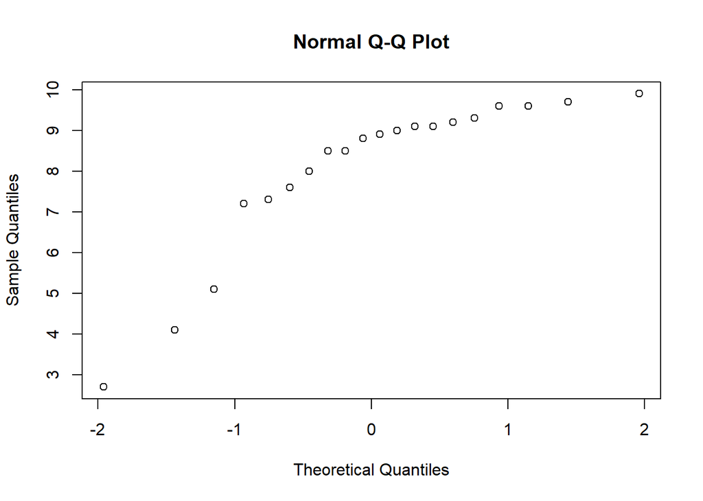

```r
qqnorm(pumpkins)
```

it is not reasonable that the population distribution is normal. It is concave down, which means it does not form a normal distribution.

## 1b.

The bootstrap code is

```r
## See the posted file bootstrap.Rmd for the bootstrap code; or here
## it is:
# Create a new function, bootstrap(x, n.boot), having two inputs:
#   - x is a data vector
#   - n.boot is the desired number of resamples from x
# It returns a vector of n.boot t-hat values.
bootstrap = function(x, n.boot) {
  n = length(x)
  x.bar = mean(x)
  t.hat = numeric(n.boot) # create vector of length n.boot zeros
  for(i in 1:n.boot) {
    x.star = sample(x, size=n, replace=TRUE)
    x.bar.star = mean(x.star)
    s.star = sd(x.star)
    t.hat[i] = (x.bar.star - x.bar) / (s.star / sqrt(n))
  }
  return(t.hat)
}
```

and I am going to run 2000 resampling.

```r
t.hats = bootstrap(pumpkins, 2000)
alpha = 0.1
x.bar = mean(pumpkins)
s = sd(pumpkins)
```

To find the CI, we need to find the quantile.

```r
t.lower = quantile(t.hats, probs = alpha / 2)
t.upper = quantile(t.hats, probs = 1 - alpha / 2)
```

And Make a CI for mu.

```r
ci.low = x.bar - t.upper * s / sqrt(n)
ci.high = x.bar - t.lower * s / sqrt(n)
ci.low
```

```
##      95%
## 6.914564
```

```r
ci.high
```

```
##       5%
## 8.657849
```

This shows the CI.

## 1c.

```r
# Null hypothesis
H_0 = 7.2
```

I will figure out if H_A: mu > 7.2 is correct or not. I will use t.hats that I already ran.

```r
alpha = 0.05
test.stat = (x.bar - H_0) / (s / sqrt(n))
m.right = sum(t.hats > test.stat)
p.value = m.right / 2000
p.value
```

```
## [1] 0.083
```

The p value is greater than alpha, so the null hypothesis that mu is 7.2 is plausible. So the conclusion is that we do not reject the null hypothesis.

## 1d.

We need to know if the median is 7.2 or not, so I will conduct the sign test.

```r
count = 0
for (x in pumpkins) {
  if (x > 7.2) {
    count = count + 1
  }
}
count
```

```
## [1] 16
```

The test statistic B is 16.

## 1e.

We need to know the P(B >= 16)

```r
sum(dbinom(x = 16:n, size = n, prob = 0.5))
```

```
## [1] 0.005908966
```

The p-value is 0.005908966

## 1f.

This is smaller than the alpha 0.05, so I reject the H_0: median = 7.2 and take H_A: median > 7.2

## 2. Penguins

```r
n = 20
m = 8 # male
f = 12 # female
```

## 2a.

the point estimation of femaie is

```r
pi = f / n
pi
```

```
## [1] 0.6
```

## 2b.

The standard deviation is

```r
var = pi * (1 - pi) / n
sd = sqrt(var)
sd
```

```
## [1] 0.1095445
```

## 2c.

Each number of success (female) and failure (male) is greater than 5, so it is reasonable to compute a 95% CI for pi using the normal approximation.

```r
alpha = 0.05
P = f / n
left = P + qnorm(alpha / 2) * sd
right = P - qnorm(alpha / 2) * sd
left
```

```
## [1] 0.3852967
```

```r
right
```

```
## [1] 0.8147033
```

So the CI is from 0.3852967 to 0.8147033

## 2d.

```r
pi_0 = 0.63
test.stat = (P - pi_0) / sqrt(pi_0 * (1 - pi_0) / n)
p.value = pnorm(q = -abs(test.stat)) + 1 - pnorm(q = abs(test.stat))
p.value
```

```
## [1] 0.7811006
```

The p value is larger than 0.05 where 0.05 is the level by default, so we do not reject the null hypothesis.